# Assignment 3.1

# (i) For a random sample of size n = 1:

The sampling distribution of Ȳ for n = 1 is identical to the population distribution. Center: Mean = 72 Spread: Standard deviation = 12 Shape: Skewed to the left. This means that if you take a single random sample from the population of Sunshine City residents, the sample mean will be the same as the value you observed for that single person. The variability of the sample mean will be the same as the variability in the population.

# (ii) If you sample all 90,000 residents:

The sampling distribution of Ȳ for n = 90,000 is a single point, equal to the population mean. Center: Mean = 72 Spread: Standard deviation = 0 Shape: A single point at 72. If you take a sample that includes the entire population, the sample mean will be exactly equal to the population mean. There is no sampling variability because you are using the entire population.

## Problem 3.21.

In your school, suppose that GPA has an approximate normal distribution with $\mu = 3.0, \sigma = 0.40.$ Not knowing $\mu$, you randomly sample $n = 25$ students to estimate it. Using simulation for this application, illustrate the difference between a sample data distribution and the sampling distribution of Y .

`Your answer here`

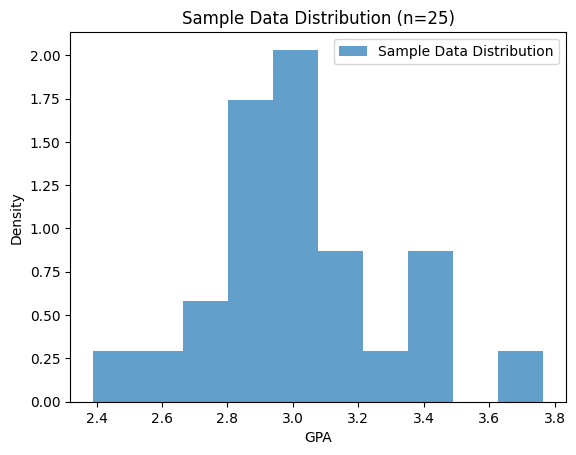

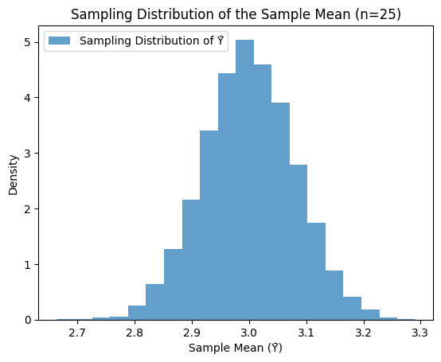

```
Sample Data Mean: 3.02
Sample Data Standard Deviation: 0.29
Sampling Distribution Mean: 3.00
Sampling Distribution Standard Deviation (Standard Error): 0.08
```

```python
import numpy as np
import matplotlib.pyplot as plt

# Population parameters
mu = 3.0
sigma = 0.40
n = 25

# Simulate a sample data distribution
sample_data = np.random.normal(loc=mu, scale=sigma, size=n)

# Plot the sample data distribution
plt.hist(sample_data, bins=10, density=True, alpha=0.7, label='Sample Data Distribution')
plt.xlabel('GPA')
plt.ylabel('Density')
plt.title('Sample Data Distribution (n=25)')
plt.legend()
plt.show()

# Simulate the sampling distribution of the sample mean
num_simulations = 10000
sample_means = []
for _ in range(num_simulations):
    sample = np.random.normal(loc=mu, scale=sigma, size=n)
    sample_means.append(np.mean(sample))

# Plot the sampling distribution of the sample mean
plt.hist(sample_means, bins=20, density=True, alpha=0.7, label='Sampling Distribution of Ȳ')
plt.xlabel('Sample Mean (Ȳ)')
plt.ylabel('Density')
plt.title('Sampling Distribution of the Sample Mean (n=25)')
plt.legend()
plt.show()

# Print some descriptive statistics
print(f"Sample Data Mean: {np.mean(sample_data):.2f}")
print(f"Sample Data Standard Deviation: {np.std(sample_data):.2f}")
print(f"Sampling Distribution Mean: {np.mean(sample_means):.2f}")
print(f"Sampling Distribution Standard Deviation (Standard Error): {np.std(sample_means):.2f}")
```

## Problem 3.26.

When sample data were used to rank states by brain cancer rates, Ellenberg (2014) noted that the highest ranking state (South Dakota) and the nearly lowest ranking state (North Dakota) had relatively small sample sizes. Also, when schools in North Carolina were ranked by their average improvement in test scores, the best and the worst schools were very small schools. Explain how these results could merely reflect how the variability of sample means and proportions depends on the sample size.

`Your answer here`

The results mentioned in the problem can be explained by the relationship between sample size and the variability of sample means/proportions.

**Larger sample sizes result in less variability in sample statistics.** This means that the sample mean or proportion is more likely to be close to the true population mean or proportion.

**Smaller sample sizes tend to have greater variability.** This can lead to extreme values in the sample statistics, potentially making them appear as outliers in the ranking.

In the case of brain cancer rates, states with smaller sample sizes are more susceptible to having a higher or lower sample mean compared to states with larger sample sizes. This means that states with smaller samples might have higher or lower brain cancer rates simply due to random chance rather than an actual difference in the population.

Similarly, the best and worst schools in North Carolina might be very small schools due to the greater variability in their sample means (average test score improvements). Smaller schools might have a few exceptionally high or low scores that significantly affect the sample mean, while larger schools are more likely to have scores that balance out, resulting in a more stable sample mean.

**In essence, when we rank entities based on sample statistics from small samples, we are more likely to see extreme results that might not accurately reflect the population.** This is because smaller samples are more susceptible to random fluctuations, which can cause them to appear as outliers in the ranking.

**Key takeaway:** Rankings based on sample statistics should always consider the sample size. Entities with very small sample sizes might have exaggerated rankings due to the greater variability inherent in smaller samples.